# CS 7324 Lab 6

### Visual Unboxing of our models

The plots of the confusion matrix are useful as we can observe which categories are mostly mistaken. From that information we could rationalize shortcomings of our models or assess similarities among animal species. We observe that except for the networks with the residual connection (cnn3 and cnn3 v2) all the others fail to learn as they are predicting always the same class. We observe a perfect classification for cnn3, which might be together with the convergence of the loss plotted above an indication of overfitting.

```python
%matplotlib inline

def summarize_net(net, X_test, y_test, title_text=''):
    plt.figure(figsize=(15,5))
    yhat = np.argmax(net.predict(X_test), axis=1)
    acc = mt.accuracy_score(y_test,yhat)
    cm = mt.confusion_matrix(y_test,yhat)
    cm = cm/np.sum(cm,axis=1)[:,np.newaxis]
    sns.heatmap(cm, annot=True, fmt='.2f')
    plt.title(title_text+'{:.4f}'.format(acc))
```

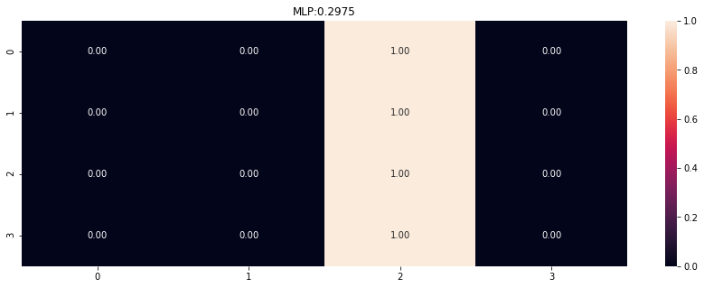

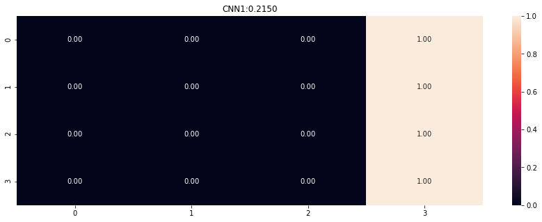

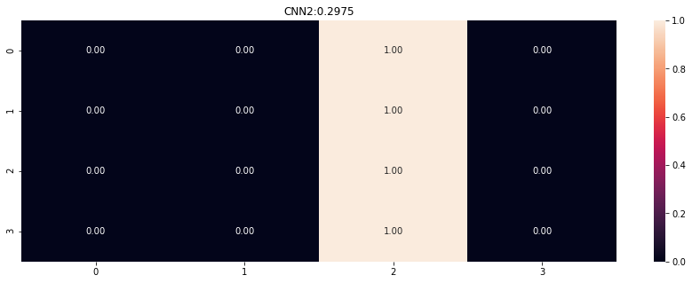

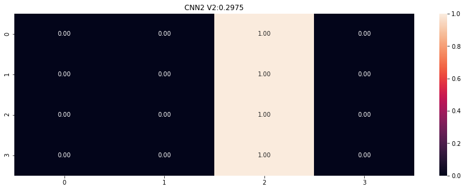

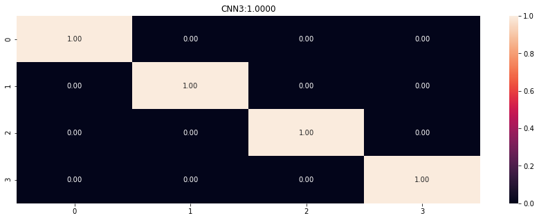

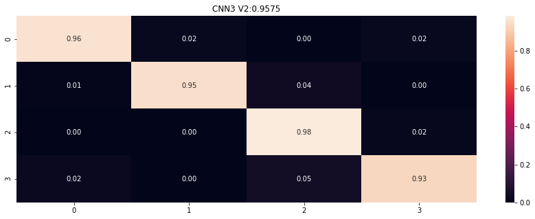

```python
summarize_net(mlp, images[test], classifications[test], title_text='MLP:')
summarize_net(cnn1, images[test], classifications[test], title_text='CNN1:')
summarize_net(cnn2, images[test], classifications[test], title_text='CNN2:')
summarize_net(cnn2_2, images[test], classifications[test], title_text='CNN2 V2:')
summarize_net(cnn3, images[test], classifications[test], title_text='CNN3:')
summarize_net(cnn3_2, images[test], classifications[test], title_text='CNN3 V2:')
```

## MLP Comparison

### Load the test set

```python
# Data for evaluation
images_mlp_comp, classifications_mlp_comp = load_images(['mlp_comp_images'])

classifications_mlp_comp = np.array(classifications , dtype=int)
classifications_mlp_comp_ohe = to_categorical(classifications_mlp_comp, NUM_CLASSES)

images_mlp_comp = np.array(images_mlp_comp, dtype=float)
max = images_mlp_comp.max()
images_mlp_comp /= max
```

```
Loading images from mlp_comp_images...
  0 images processed
  100 images processed
  200 images processed
  300 images processed
  400 images processed
  500 images processed
  600 images processed
  700 images processed
  800 images processed
  900 images processed
  1000 images processed
  1100 images processed
  1200 images processed
  1300 images processed
```

[output cut: 1769 more lines]

### ROC Comparison

```python
def compute_curve(y_test, y_score):
    # Compute ROC curve and ROC area for each class
    fpr = dict()
    tpr = dict()
    roc_auc = dict()
    for i in range(NUM_CLASSES):
        fpr[i], tpr[i], _ = roc_curve(y_test[:, i], y_score[:, i])
        roc_auc[i] = auc(fpr[i], tpr[i])

    # Compute micro-average ROC curve and ROC area
    fpr["micro"], tpr["micro"], _ = roc_curve(y_test.ravel(), y_score_mlp.ravel())
    roc_auc["micro"] = auc(fpr["micro"], tpr["micro"])

    return fpr, tpr, roc_auc
```

```python
def plot_curve(fpr_cnn, tpr_cnn, roc_auc_cnn, fpr_mlp, tpr_mlp, roc_auc_mlp):
    for i in range(NUM_CLASSES):
        plt.figure()
        plt.plot(fpr_cnn[i], tpr_cnn[i], label='CNN (area = %0.2f)' % roc_auc_cnn[i])
        plt.plot(fpr_mlp[i], tpr_mlp[i], label='MLP (area = %0.2f)' % roc_auc_mlp[i])
        plt.xlabel('False Positive Rate')
        plt.ylabel('True Positive Rate')
        plt.title('Receiver operating characteristic: {}'.format(decode_classifier(i)))
        plt.legend(loc="lower right")
        plt.show()
```

```python
y_score_mlp = mlp.predict(images_mlp_comp)
fpr_mlp, tpr_mlp, roc_auc_mlp = compute_curve(classifications_mlp_comp_ohe, y_score_mlp)

y_score_cnn = cnn3_2.predict(images_mlp_comp)
fpr_cnn, tpr_cnn, roc_auc_cnn = compute_curve(classifications_mlp_comp_ohe, y_score_cnn)
```

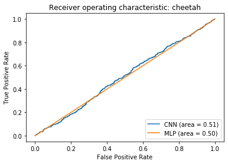

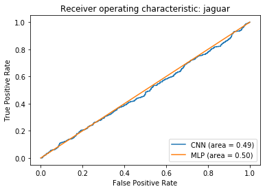

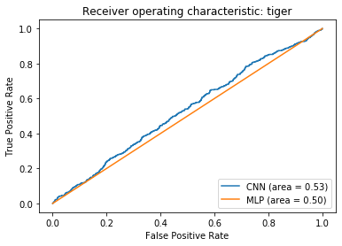

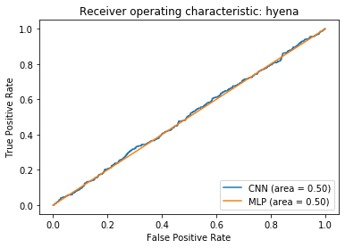

```python
plot_curve(fpr_cnn, tpr_cnn, roc_auc_cnn, fpr_mlp, tpr_mlp, roc_auc_mlp)
```

### ROC Analysis

As shown above neither model is learning. An additional confirmation comes from the analysis the ROC, which show that both models follow a straight diagonal line, indicating a lack of enrichment compared to chance.

### Statistical Test - McNemar

```python
models_titles = ['MLP', 'CNN']
comps = []

yhat = np.argmax(y_score_mlp, axis=1)
comp = np.equal(yhat, classifications_mlp_comp)
comps.append(comp)

yhat = np.argmax(y_score_cnn, axis=1)
comp = np.equal(yhat, classifications_mlp_comp)
comps.append(comp)

compare_comps(comps)
```

```
MLP vs CNN
statistic=0.082, p-value=0.774
No meaningful difference in performance (fail to reject H0)
-----------------------------------------------------------
```

### Statistical Conclusion

We observe no meaningful difference between the models, once again as they are not actually learning.

# Exceptional Work - Transfer Learning

## Transfer Learning

We're going to do is create a third dataset by agumenting the images similar to what we did in the data expansion exercise. However, here, we're always flipping the images on the vertical access to create a mirror of the original. Then we will make some minor rotations, etc.